# Wind data comparison

*Raynaldi Pratama*

08/03/2021

**Notes:** Another addition to the previous wind energy-related portfolios, explaining methods on wind data comparison between Bilbao-Vizcaya buoy dataset, as a reference, and ERA-Interim model.

**Library setup:**

```r
# Working with table
library(kableExtra)

# NetCDF in R
library(RNetCDF)

# Argos location filter
library(argosfilter)

# World map data from Natural Earth
library(rnaturalearth)
library(rnaturalearthdata)

# Data visualization
library(ggplot2)
library(ggspatial)

# Manipulating and analysing data
library(tidyverse)

# Wind components transformation
library(rWind)

# Wind rose plot
library(openair)

# Taylor diagram
library(plotrix)

# Evaluation metrics
library(Metrics)
```

## ERAI wind data Oct-2011

### Load the data

The ERAI data that we are going to use here is for the October 2011 records. In the next analysis, where the buoy data is used for comparison, we have to ensure that the corresponding timeframe should follow the ERAI model accordingly.

```r
ncdata <- open.nc("ERA-Interim Oct 2011.nc") # Find the corresponding dataset inside 00_data/

print.nc(ncdata)
```

```
## netcdf offset64 {
## dimensions:
##  longitude = 97 ;
##  latitude = 55 ;
##  time = UNLIMITED ; // (124 currently)
## variables:
##  NC_FLOAT longitude(longitude) ;
##      NC_CHAR longitude:units = "degrees_east" ;
##      NC_CHAR longitude:long_name = "longitude" ;
##  NC_FLOAT latitude(latitude) ;
##      NC_CHAR latitude:units = "degrees_north" ;
##      NC_CHAR latitude:long_name = "latitude" ;
##  NC_INT time(time) ;
##      NC_CHAR time:units = "hours since 1900-01-01 00:00:00.0" ;
##      NC_CHAR time:long_name = "time" ;
##      NC_CHAR time:calendar = "gregorian" ;
##  NC_SHORT sp(longitude, latitude, time) ;
##      NC_DOUBLE sp:scale_factor = 0.40547224299208 ;
##      NC_DOUBLE sp:add_offset = 90468.9535138785 ;
##      NC_SHORT sp:_FillValue = -32767 ;
##      NC_SHORT sp:missing_value = -32767 ;
##      NC_CHAR sp:units = "Pa" ;
##      NC_CHAR sp:long_name = "Surface pressure" ;
##      NC_CHAR sp:standard_name = "surface_air_pressure" ;
##  NC_SHORT u10(longitude, latitude, time) ;
##      NC_DOUBLE u10:scale_factor = 0.000732297887006534 ;
##      NC_DOUBLE u10:add_offset = -0.362934050554831 ;
##      NC_SHORT u10:_FillValue = -32767 ;
##      NC_SHORT u10:missing_value = -32767 ;
##      NC_CHAR u10:units = "m s**-1" ;
##      NC_CHAR u10:long_name = "10 metre U wind component" ;
##  NC_SHORT v10(longitude, latitude, time) ;
##      NC_DOUBLE v10:scale_factor = 0.000777025187706599 ;
##      NC_DOUBLE v10:add_offset = -1.2680505609337 ;
##      NC_SHORT v10:_FillValue = -32767 ;
##      NC_SHORT v10:missing_value = -32767 ;
##      NC_CHAR v10:units = "m s**-1" ;
##      NC_CHAR v10:long_name = "10 metre V wind component" ;
##  NC_SHORT t2m(longitude, latitude, time) ;
##      NC_DOUBLE t2m:scale_factor = 0.00105876316346881 ;
##      NC_DOUBLE t2m:add_offset = 276.906399634532 ;
##      NC_SHORT t2m:_FillValue = -32767 ;
##      NC_SHORT t2m:missing_value = -32767 ;
##      NC_CHAR t2m:units = "K" ;
##      NC_CHAR t2m:long_name = "2 metre temperature" ;
##
## // global attributes:
##      NC_CHAR :Conventions = "CF-1.6" ;
##      NC_CHAR :history = "2019-03-08 08:30:22 GMT by grib_to_netcdf-2.12.0: grib_to_netcdf /data/data02/scratch/2e/a7/_mars-atls01-a82bacafb5c306db76464bc7e824bb75-v76O6k.grib -o /data/data02/scratch/f2/7c/_grib2netcdf-atls02-a82bacafb5c306db76464bc7e824bb75-lcQXym.nc -utime" ;
## }
```

From the results above, we can inspect the content of **`ncdata`**, including dimensions, variables and global attributes. Afterwards, suppose we want to know the length of the data recorded during this period, we could pass the desired argument inside **`var.get.nc()`**. In this case, **`ncdata`** as the main dataset and **`"time"`** to get the number of recording time.

```r
# Retrieve number of recording time
time <- var.get.nc(ncdata, "time")

length(time)
```

```
## [1] 124
```

We should keep in mind that the recording time from the dataset above is 124, as we might want to use this information in the next analysis.

### Identify the nearest grid point location

In this part, we would like to identify the nearest grid point location to the Bilbao-Vizcaya buoy. Of all grid points covered in this dataset, we can obtain the one located near the buoy and get the relative distance by doing several steps below. Afterwards, we will extract the wind data from the corresponding location to compare with the one provided by the buoy. To start, we can use the similar way as we did previously, but this time we should pass the argument **`"longitude"`** and **`"latitude"`** inside **`var.get.nc()`** to get the desired grid points.

```r
lon <- var.get.nc(ncdata, "longitude")

lon
```

```
##  [1] -27.00 -26.25 -25.50 -24.75 -24.00 -23.25 -22.50 -21.75 -21.00 -20.25
## [11] -19.50 -18.75 -18.00 -17.25 -16.50 -15.75 -15.00 -14.25 -13.50 -12.75
## [21] -12.00 -11.25 -10.50  -9.75  -9.00  -8.25  -7.50  -6.75  -6.00  -5.25
## [31]  -4.50  -3.75  -3.00  -2.25  -1.50  -0.75   0.00   0.75   1.50   2.25
## [41]   3.00   3.75   4.50   5.25   6.00   6.75   7.50   8.25   9.00   9.75
## [51]  10.50  11.25  12.00  12.75  13.50  14.25  15.00  15.75  16.50  17.25
## [61]  18.00  18.75  19.50  20.25  21.00  21.75  22.50  23.25  24.00  24.75
## [71]  25.50  26.25  27.00  27.75  28.50  29.25  30.00  30.75  31.50  32.25
## [81]  33.00  33.75  34.50  35.25  36.00  36.75  37.50  38.25  39.00  39.75
## [91]  40.50  41.25  42.00  42.75  43.50  44.25  45.00
```

```r
lat <- var.get.nc(ncdata, "latitude")

lat
```

```
##  [1] 73.50 72.75 72.00 71.25 70.50 69.75 69.00 68.25 67.50 66.75 66.00 65.25
## [13] 64.50 63.75 63.00 62.25 61.50 60.75 60.00 59.25 58.50 57.75 57.00 56.25
## [25] 55.50 54.75 54.00 53.25 52.50 51.75 51.00 50.25 49.50 48.75 48.00 47.25
## [37] 46.50 45.75 45.00 44.25 43.50 42.75 42.00 41.25 40.50 39.75 39.00 38.25
## [49] 37.50 36.75 36.00 35.25 34.50 33.75 33.00
```

Subsequently, to find the desired point, we first need to specify the Bilbao-Vizcaya buoy location. The idea is to find the minimum value (closest distance) by subtracting **`lon`** and **`lat`** we obtained before with the buoy coordinates.

```r
buoy_lon <- -3.04 # Bilbao-Vizcaya buoy

buoy_lat <- 43.63 # Bilbao-Vizcaya buoy

identified_lon <- which.min(abs(lon - buoy_lon))

identified_lat <- which.min(abs(lat - buoy_lat))
```

Finally, we can now extract the nearest grid point coordinates from the information we obtained above and determine its relative distance from the buoy.

```r
nearest_lon <- lon[identified_lon]

nearest_lon
```

```
## [1] -3
```

```r
nearest_lat <- lat[identified_lat]

nearest_lat
```

```
## [1] 43.5
```

```r
dist <- distance(buoy_lat, nearest_lat, buoy_lon, nearest_lon)

dist # Given distance in km
```

```
## [1] 14.80027
```

To complete the steps, one might want to create a map visualization to see where the nearest grid point is located relative to the buoy location.

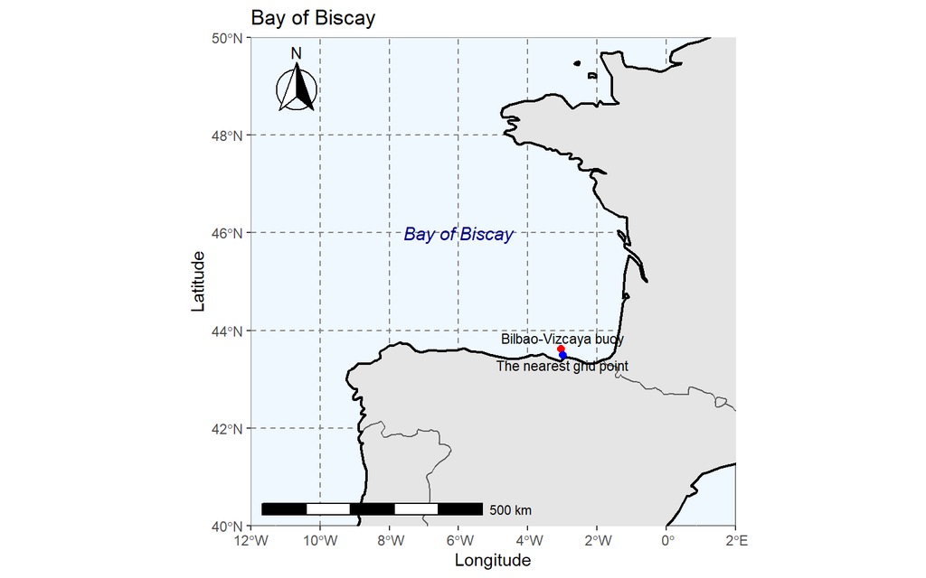

```r
spdf_world <- ne_countries(scale = "medium", returnclass = "sf") # Spatial polygons df

sldf_world <- ne_coastline(scale = "medium", returnclass = "sf") # Spatial lines df

ggplot() +
  geom_sf(data = spdf_world) +
  geom_sf(data = sldf_world, size = 0.75) +
  annotation_scale(width_hint = 0.5, location = "bl") +
  annotation_north_arrow(
    location = "tl",
    height = unit(1.5, "cm"),
    width = unit(1.5, "cm"),
    pad_x = unit(0.25, "cm"),
    pad_y = unit(0.25, "cm"),
    style = north_arrow_fancy_orienteering
  ) +
  annotate(
    geom = "text",
    x = -6,
    y = 46,
    label = "Bay of Biscay",
    fontface = "italic",
    color = "darkblue",
    size = 4
  ) +
  annotate(
    geom = "point",
    x = -3.04,
    y = 43.63,
    colour = "red",
    size = 2
  ) +
  annotate(
    geom = "text",
    x = -3,
    y = 43.85,
    label = "Bilbao-Vizcaya buoy",
    size = 3
  ) +
  annotate(
    geom = "point",
    x = -3,
    y = 43.5,
    colour = "blue",
    size = 2
  ) +
  annotate(
    geom = "text",
    x = -3,
    y = 43.3,
    label = "The nearest grid point",
    size = 3
  ) +
  coord_sf(xlim = c(-12, 2), ylim = c(40, 50), expand = FALSE) +
  theme(
    panel.grid.major = element_line(
      color = gray(0.5), linetype = "dashed", size = 0.5
    ),
    panel.background = element_rect(fill = "aliceblue")
  ) +
  xlab("Longitude") +
  ylab("Latitude") +
  ggtitle("Bay of Biscay")
```

### Extract wind components

The codes written below shows how to extract both wind components, zonal and meridional. The reading (extraction) starts from the nearest grid point elements. The results should be of 124 lengths of data.

```r
# Zonal component
U <- var.get.nc(ncdata, "u10",
  start = c(identified_lon, identified_lat, 1),
  count = c(1, 1, length(time)), unpack = TRUE
)

# Meridional component
V <- var.get.nc(ncdata, "v10",
  start = c(identified_lon, identified_lat, 1),
  count = c(1, 1, length(time)), unpack = TRUE
)
```

### ERAI wind model

Finally, we can now determine the ERAI wind data (model) according to its zonal and meridional components using the common formula applied in the line of code below.

```r
windModel <- sqrt(U^2 + V^2)

summary(windModel)
```

```
##    Min. 1st Qu.  Median    Mean 3rd Qu.    Max.
##  0.3883  2.3914  3.5363  3.7302  4.7195  9.7909
```

```r
length(windModel)
```

```
## [1] 124
```

## Bilbao-Vizcaya buoy data

### Load the data

As mentioned before, since the available ERAI dataset is only available for the Oct-2011 records, we should then select the appropriate time frame within our buoy dataset to match our ERAI dataset.

```r
buoydata <- read.table("BilbaoVizcaya.txt", header = TRUE)

buoydata_oct2011 <- buoydata %>%
  filter(buoydata$AA == "2011" &
    buoydata$MM == "10")

kbl(summary(buoydata_oct2011)) %>%
  kable_paper() %>%
  scroll_box(width = "100%", height = "300px")
```

|  | AA | MM | DD | HH | Hm0 | Tm02 | Tp | Hmax | Thmax | Pro_Oe | Dmd | Dmd_P | Ds_P | Pro_Od | Ts2 | Sa2 | Vc_md | Dc_md | Pro_Oce | Ps | Ta | Vv_md | Dv_md | Pro_Met | Qc_e |
| --- | --- | --- | --- | --- | --- | --- | --- | --- | --- | --- | --- | --- | --- | --- | --- | --- | --- | --- | --- | --- | --- | --- | --- | --- | --- |
|  | Min. :2011 | Min. :10 | Min. : 1 | Min. : 0.00 | Min. :0.500 | Min. : 3.000 | Min. : 3.20 | Min. :0.600 | Min. : 3.30 | Min. :1 | Min. : 0.0 | Min. : 6.0 | Min. :10.00 | Min. :1 | Length:744 | Length:744 | Length:744 | Length:744 | Min. :2 | Min. : 989 | Min. :13.30 | Min. : 0.000 | Min. : 0.0 | Min. :2 | Min. :1.000 |
|  | 1st Qu.:2011 | 1st Qu.:10 | 1st Qu.: 8 | 1st Qu.: 5.75 | 1st Qu.:1.000 | 1st Qu.: 4.500 | 1st Qu.: 9.10 | 1st Qu.:1.500 | 1st Qu.: 8.30 | 1st Qu.:1 | 1st Qu.:293.0 | 1st Qu.:301.0 | 1st Qu.:21.00 | 1st Qu.:1 | Class :character | Class :character | Class :character | Class :character | 1st Qu.:2 | 1st Qu.:1018 | 1st Qu.:16.70 | 1st Qu.: 2.450 | 1st Qu.: 84.0 | 1st Qu.:2 | 1st Qu.:1.000 |
|  | Median :2011 | Median :10 | Median :16 | Median :11.50 | Median :1.600 | Median : 6.000 | Median :10.00 | Median :2.500 | Median :10.00 | Median :1 | Median :311.0 | Median :311.0 | Median :24.00 | Median :1 | Mode :character | Mode :character | Mode :character | Mode :character | Median :2 | Median :1022 | Median :18.20 | Median : 4.600 | Median :160.0 | Median :2 | Median :1.000 |
|  | Mean :2011 | Mean :10 | Mean :16 | Mean :11.50 | Mean :1.782 | Mean : 6.141 | Mean :10.16 | Mean :2.746 | Mean :10.06 | Mean :1 | Mean :274.8 | Mean :295.5 | Mean :25.87 | Mean :1 | NA | NA | NA | NA | Mean :2 | Mean :1019 | Mean :18.26 | Mean : 4.579 | Mean :170.8 | Mean :2 | Mean :1.017 |
|  | 3rd Qu.:2011 | 3rd Qu.:10 | 3rd Qu.:24 | 3rd Qu.:17.25 | 3rd Qu.:2.500 | 3rd Qu.: 7.100 | 3rd Qu.:11.10 | 3rd Qu.:3.800 | 3rd Qu.:11.80 | 3rd Qu.:1 | 3rd Qu.:321.0 | 3rd Qu.:316.0 | 3rd Qu.:29.00 | 3rd Qu.:1 | NA | NA | NA | NA | 3rd Qu.:2 | 3rd Qu.:1025 | 3rd Qu.:19.52 | 3rd Qu.: 6.500 | 3rd Qu.:255.0 | 3rd Qu.:2 | 3rd Qu.:1.000 |
|  | Max. :2011 | Max. :10 | Max. :31 | Max. :23.00 | Max. :4.300 | Max. :13.100 | Max. :16.70 | Max. :8.200 | Max. :20.20 | Max. :1 | Max. :359.0 | Max. :354.0 | Max. :78.00 | Max. :1 | NA | NA | NA | NA | Max. :2 | Max. :1030 | Max. :24.40 | Max. :14.200 | Max. :357.0 | Max. :2 | Max. :3.000 |

### Match both wind data

```r
# Match wind data from buoy with 6-hourly sequence of ERAI
seq_6h <- seq(0, nrow(buoydata_oct2011), 6)

seq_6h
```

```
##   [1]   0   6  12  18  24  30  36  42  48  54  60  66  72  78  84  90  96 102
##  [19] 108 114 120 126 132 138 144 150 156 162 168 174 180 186 192 198 204 210
##  [37] 216 222 228 234 240 246 252 258 264 270 276 282 288 294 300 306 312 318
##  [55] 324 330 336 342 348 354 360 366 372 378 384 390 396 402 408 414 420 426
##  [73] 432 438 444 450 456 462 468 474 480 486 492 498 504 510 516 522 528 534
##  [91] 540 546 552 558 564 570 576 582 588 594 600 606 612 618 624 630 636 642
## [109] 648 654 660 666 672 678 684 690 696 702 708 714 720 726 732 738 744
```

```r
windSpeed <- buoydata_oct2011[seq_6h, 22] # Column 22 (Vv_md)

windSpeed
```

```
##   [1]  4.9  5.1  6.7  2.1  4.2  2.3  3.5  0.4  2.3  1.8  1.4  2.3  3.5  1.1  4.2
##  [16]  0.4  2.1  0.4  5.1  1.8  3.2  7.0  7.0  8.9  8.6  7.2  9.8  6.3  6.7  4.2
##  [31]  4.9  5.8  4.2  3.5  0.0  3.7  3.9  6.7  6.3  3.7  1.8  4.2  4.4  3.2  2.1
##  [46]  0.4  4.9  3.7  6.3  7.0  4.9  2.1  0.4  2.5  5.1  2.1  0.9  0.0  0.0  0.2
##  [61]  1.1  0.0  3.0  3.0  4.6  4.6  5.3  8.6  7.0  6.3  3.9  4.9  9.8  7.0  7.2
##  [76]  4.4  3.0  5.3  3.2  4.4  6.0  7.0  8.2  5.1  8.2  8.2  3.2  7.5  9.6  5.3
##  [91]  6.0  6.0 13.1  7.5  7.5  4.2  5.1  5.8  8.6  2.3  6.7  7.2  7.9 11.4  6.5
## [106]  7.5  6.5 11.4 11.0  9.3  6.7  4.6  3.7  1.4  0.2  0.9  1.6  0.0  5.3  5.1
## [121]  2.3  1.6  3.0  9.8
```

### Transform wind speed to 10 m height

```r
windSpeed10 <- windSpeed * log(10 / 0.0005) / log(3 / 0.0005)

summary(windSpeed10)
```

```
##    Min. 1st Qu.  Median    Mean 3rd Qu.    Max.
##   0.000   2.618   5.237   5.380   7.627  14.913
```

### Verify the length of wind data

```r
length(windSpeed10) # Bibao-Vizcaya buoy
```

```
## [1] 124
```

```r
length(windModel) # ERA-Interim
```

```
## [1] 124
```

### Plot both wind data

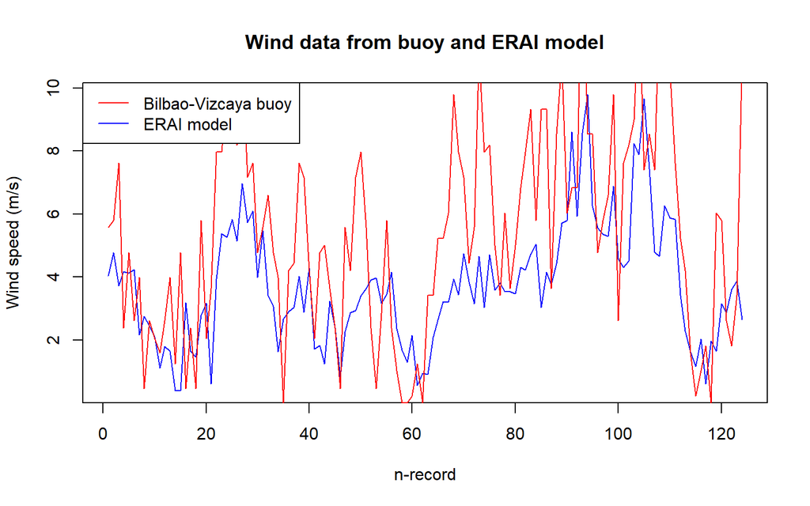

```r
plot(c(1:length(windSpeed10)), windModel,
  type = "l",
  main = "Wind data from buoy and ERAI model",
  xlab = "n-record",
  ylab = "Wind speed (m/s)",
  col = "blue"
)

lines(windSpeed10, col = "red")

legend("topleft",
  col = c("red", "blue"),
  lty = 1,
  legend = c("Bilbao-Vizcaya buoy", "ERAI model")
)
```

The figure above shows that the data records represented by the buoy are generally larger than the ones provided by the model. However, both graphs share a relatively similar trend throughout the records.

## Box plot and wind rose

### Box plot

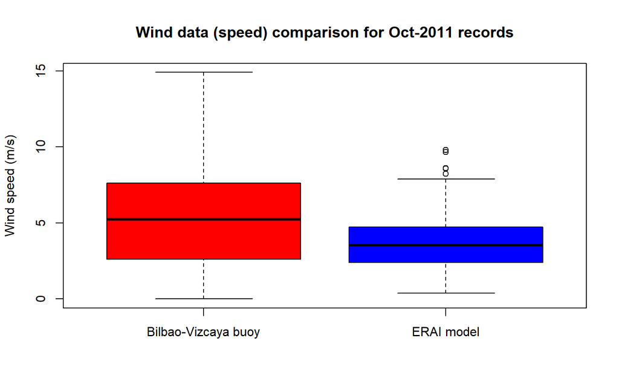

```r
boxplot(windSpeed10, windModel,
  col = c("red", "blue"),
  names = c("Bilbao-Vizcaya buoy", "ERAI model"),
  ylab = "Wind speed (m/s)",
  main = "Wind data (speed) comparison for Oct-2011 records"
)
```

Another visualization presented in box plots shows the difference in wind speed data between the buoy and ERAI models. It can be seen that the average value presented by the buoy is just above 5 m/s, larger than it is shown by the model, where the average wind speed is around 4 m/s.

### Wind rose

Below are codes we are going to use to create a wind rose plot based on the data provided by the buoy for the Oct-2011 records.

```r
# Bilbao-Vizcaya buoy
year <- buoydata_oct2011$AA

month <- buoydata_oct2011$MM

day <- buoydata_oct2011$DD

hour <- buoydata_oct2011$HH

wind_spd <- buoydata_oct2011$Vv_md

wind_dir <- buoydata_oct2011$Dv_md

wind_df <- data.frame(year, month, day, hour, wind_spd, wind_dir)

kbl(wind_df) %>%
  kable_paper() %>%
  scroll_box(width = "100%", height = "300px")
```

| year | month | day | hour | wind_spd | wind_dir |
| --- | --- | --- | --- | --- | --- |
| 2011 | 10 | 1 | 0 | 4.6 | 146 |
| 2011 | 10 | 1 | 1 | 3.7 | 146 |
| 2011 | 10 | 1 | 2 | 4.4 | 151 |
| 2011 | 10 | 1 | 3 | 3.2 | 129 |
| 2011 | 10 | 1 | 4 | 4.4 | 135 |
| 2011 | 10 | 1 | 5 | 4.9 | 126 |
| 2011 | 10 | 1 | 6 | 4.4 | 143 |
| 2011 | 10 | 1 | 7 | 5.1 | 135 |
| 2011 | 10 | 1 | 8 | 5.6 | 151 |
| 2011 | 10 | 1 | 9 | 6.5 | 157 |
| 2011 | 10 | 1 | 10 | 6.0 | 149 |
| 2011 | 10 | 1 | 11 | 5.1 | 149 |
| 2011 | 10 | 1 | 12 | 3.5 | 73 |
| 2011 | 10 | 1 | 13 | 3.9 | 59 |
| 2011 | 10 | 1 | 14 | 4.4 | 61 |
| 2011 | 10 | 1 | 15 | 5.1 | 67 |
| 2011 | 10 | 1 | 16 | 5.3 | 61 |
| 2011 | 10 | 1 | 17 | 6.7 | 84 |
| 2011 | 10 | 1 | 18 | 5.3 | 81 |
| 2011 | 10 | 1 | 19 | 4.6 | 95 |
| 2011 | 10 | 1 | 20 | 3.7 | 95 |
| 2011 | 10 | 1 | 21 | 5.3 | 112 |
| 2011 | 10 | 1 | 22 | 4.2 | 118 |
| 2011 | 10 | 1 | 23 | 2.1 | 129 |
| 2011 | 10 | 2 | 0 | 3.2 | 56 |
| 2011 | 10 | 2 | 1 | 4.6 | 115 |
| 2011 | 10 | 2 | 2 | 4.9 | 129 |
| 2011 | 10 | 2 | 3 | 4.6 | 135 |
| 2011 | 10 | 2 | 4 | 5.1 | 135 |
| 2011 | 10 | 2 | 5 | 4.2 | 135 |

[output cut: 714 more lines]

```r
windRose(wind_df,
  ws = "wind_spd",
  wd = "wind_dir",
  ws.int = 4,
  angle = 22.5,
  cols = "hue",
  paddle = FALSE
)
```

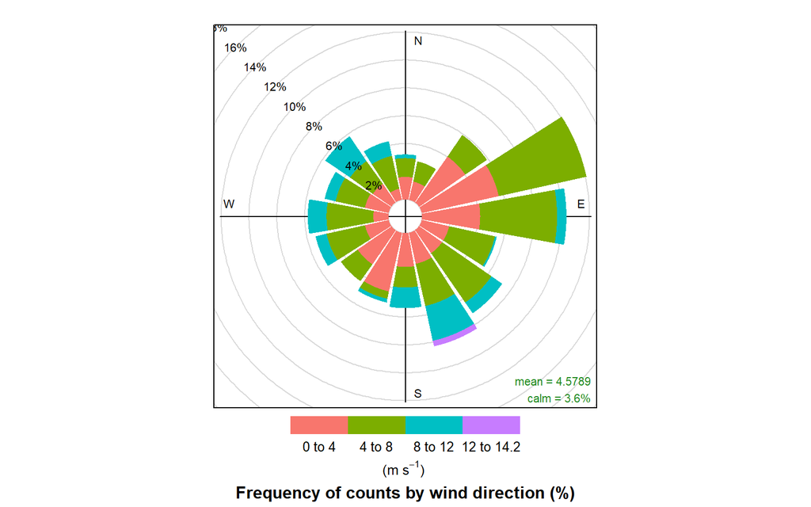

A similar method may also be used to visualize a wind rose plot of the ERAI model. However, it should be noted that before we proceed, such wind components transformation is needed and can be done by passing both **`U`** and **`V`** objects inside **`uv2ds()`** command.

```r
# ERA-Interim (option 1)
wind_df_erai <- as.data.frame(uv2ds(-U, -V))

names(wind_df_erai)[1] <- "Wind Direction"

names(wind_df_erai)[2] <- "Wind Speed"

kbl(wind_df_erai) %>%
  kable_paper() %>%
  scroll_box(width = "100%", height = "300px")
```

| Wind Direction | Wind Speed |
| --- | --- |
| 155.223541 | 4.0462918 |
| 172.571832 | 4.7784563 |
| 151.632174 | 3.7230765 |
| 109.640904 | 4.1820668 |
| 153.836086 | 4.1313303 |
| 177.870255 | 4.2486550 |
| 166.031452 | 2.1739656 |
| 91.744241 | 2.7588264 |
| 190.056043 | 2.4424701 |
| 229.509632 | 2.1062318 |
| 296.264263 | 1.1043641 |
| 6.341197 | 1.7941955 |
| 260.353724 | 1.6418785 |
| 311.621960 | 0.3883060 |
| 319.567775 | 0.3888627 |
| 40.873688 | 3.1854931 |
| 48.941277 | 1.6525524 |
| 121.289605 | 1.4573150 |
| 85.948039 | 2.7813433 |
| 78.503479 | 3.1614964 |
| 176.486020 | 0.6166178 |
| 274.384733 | 3.9325184 |
| 302.963334 | 5.3837868 |
| 322.291770 | 5.2564741 |
| 329.347124 | 5.8321063 |
| 339.723533 | 5.1398993 |
| 328.499833 | 6.9633191 |
| 335.781087 | 5.7237806 |
| 347.050986 | 6.0992941 |
| 357.546747 | 3.9928523 |

[output cut: 94 more lines]

```r
windRose(wind_df_erai,
  ws = "Wind Speed",
  wd = "Wind Direction",
  ws.int = 4,
  angle = 22.5,
  cols = "hue",
  paddle = FALSE
)
```

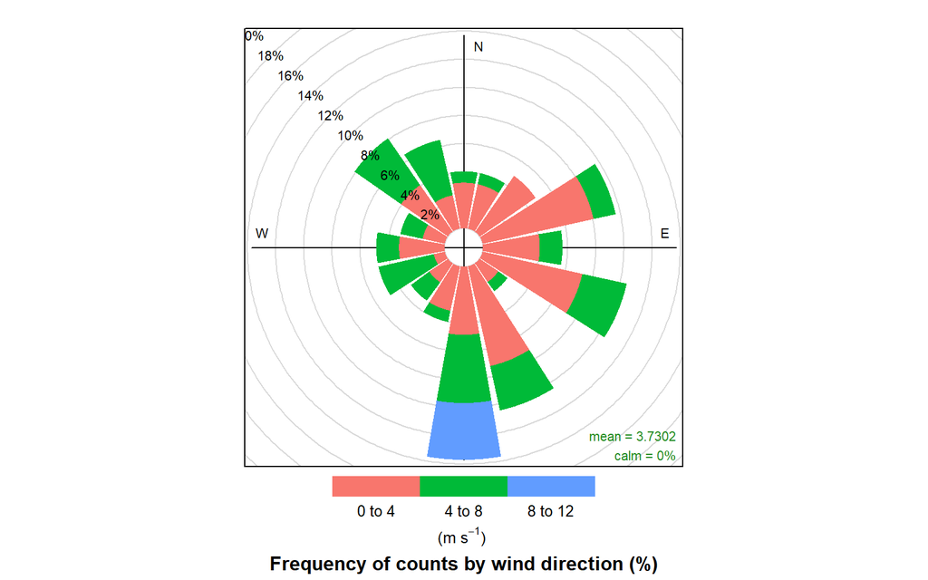

Another way to get through the wind components transformation, we can build a user-defined function instead of using **`uv2ds()`** command. Although it might look more complex, this way, we can avoid any misconception regarding the object signs (+) or (-), according to the wind direction’s general convention.

```r
# ERA-Interim (option 2); a user-defined function
uv2wdws <- function(u, v) {

  # Radians to degrees transformation
  degrees <- function(radians) 180 * radians / pi

  # Apply degrees() to convert radians to degrees; use atan2() inside degrees()
  # to determine the angle from both wind components
  angle <- degrees(atan2(v, u))

  # Fix negative angles from the previous section and change the wind rose
  # convention to show from which direction the wind comes from
  wind_dir_fix <- ifelse(angle > 0, angle, angle + 360)

  wind_dir <- ifelse(wind_dir_fix < 270,
    270 - wind_dir_fix, 270 - wind_dir_fix + 360
  )

  wind_spd <- sqrt(u^2 + v^2)

  return(cbind(wind_dir, wind_spd))
}

wind_df_erai <- as.data.frame(uv2wdws(U, V))

names(wind_df_erai)[1] <- "Wind Direction"

names(wind_df_erai)[2] <- "Wind Speed"

kbl(wind_df_erai) %>%
  kable_paper() %>%
  scroll_box(width = "100%", height = "300px")
```

| Wind Direction | Wind Speed |
| --- | --- |
| 155.223541 | 4.0462918 |
| 172.571832 | 4.7784563 |
| 151.632174 | 3.7230765 |
| 109.640904 | 4.1820668 |
| 153.836086 | 4.1313303 |
| 177.870255 | 4.2486550 |
| 166.031452 | 2.1739656 |
| 91.744241 | 2.7588264 |
| 190.056043 | 2.4424701 |
| 229.509632 | 2.1062318 |
| 296.264263 | 1.1043641 |
| 6.341197 | 1.7941955 |
| 260.353724 | 1.6418785 |
| 311.621960 | 0.3883060 |
| 319.567775 | 0.3888627 |
| 40.873688 | 3.1854931 |
| 48.941277 | 1.6525524 |
| 121.289605 | 1.4573150 |
| 85.948039 | 2.7813433 |
| 78.503479 | 3.1614964 |
| 176.486020 | 0.6166178 |
| 274.384733 | 3.9325184 |
| 302.963334 | 5.3837868 |
| 322.291770 | 5.2564741 |
| 329.347124 | 5.8321063 |
| 339.723533 | 5.1398993 |
| 328.499833 | 6.9633191 |
| 335.781087 | 5.7237806 |
| 347.050986 | 6.0992941 |
| 357.546747 | 3.9928523 |

[output cut: 94 more lines]

```r
windRose(wind_df_erai,
  ws = "Wind Speed",
  wd = "Wind Direction",
  ws.int = 4,
  angle = 22.5,
  cols = "hue",
  paddle = FALSE
)
```

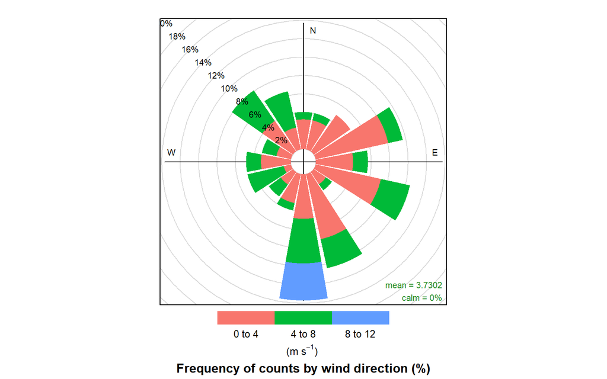

## Taylor diagram

The Taylor diagram in R is available through **`plotrix`** package. This diagram allows us to compare two data by representing three parameters at once in the same plot. These parameters are including Standard Deviation, Root Mean Square Error (RMSE), and Correlation.

### Wind speed data

```r
taylor.diagram(windSpeed10, windModel,
  pch = 19,
  pos.cor = TRUE,
  xlab = "Standard deviation",
  ylab = "Standard deviation",
  main = "Taylor Diagram",
  ngamma = 10,
  gamma.col = "green",
  sd.arcs = TRUE,
  pcex = 1.5
)
```

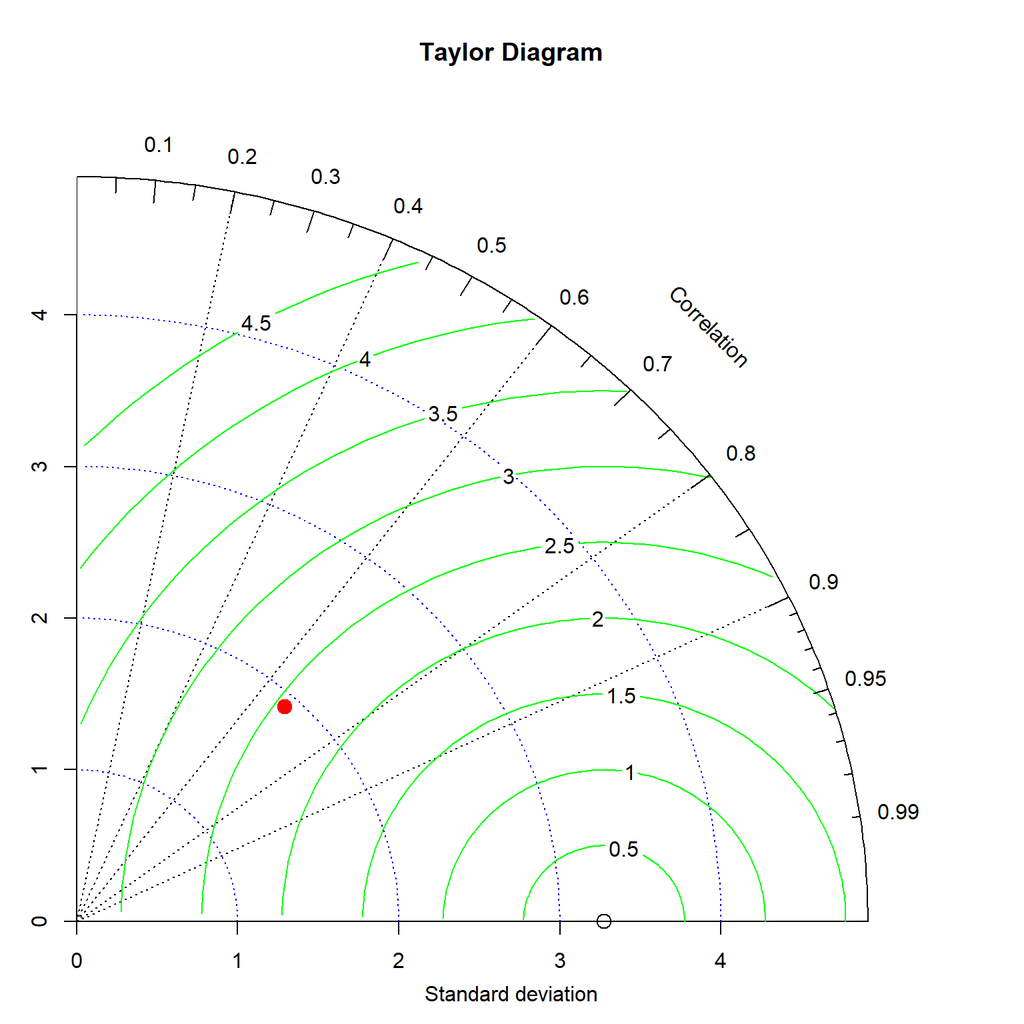

According to the figure above, we may see the model representation in the red dot object. From that object, we can conclude that the ERAI dataset (model) has a Standard Deviation value of around **1.9** by following the XY-axis and the blue arc. For the model’s RMSE value, we might want to refer to the green arc, where it is nearly **2.5**. Simultaneously, the Correlation value can be traced from the dashed line, which, in this case, is above **0.65**. Additionally, we can also see the buoy data represented in a black-outlined circle showing the Standard Deviation value of around **3.2**.

### Evaluate the taylor diagram

Below are several ways to manually evaluate the Taylor diagram using some commands corresponding to the three parameters presented previously.

```r
# Standard deviation of ERA-Interim model
sd(windModel)
```

```
## [1] 1.924542
```

```r
# Standard deviation of buoy data
sd(windSpeed10)
```

```
## [1] 3.287703
```

```r
# RMSE
rmse(windSpeed10, windModel)
```

```
## [1] 2.941214
```

```r
# Correlation value
cor(windSpeed10, windModel)
```

```
## [1] 0.6744836
```

From the results above, we can see that almost all values are similar to what has been presented by the diagram. The only difference is the RMSE value of **2.94**. The difference thus suggests the upper and lower limit for the RMSE value for further necessary analysis. In any case, both model and buoy data follow the same pattern in terms of the overall behaviour, represented by a good correlation value of **0.674**.

### Wind speed components

By following the previous steps, the Taylor diagram may also be used to evaluate the buoy’s wind components data (zonal/meridional) over the wind speed provided by the model (combined zonal-meridional). The remaining process is covered in the lines of codes written below.

```r
# Match wind data from buoy with 6-hourly sequence of ERAI
windDirection <- buoydata_oct2011[seq_6h, 23] # Column 23 (Dv_md)

windDirection
```

```
##   [1] 126 149  84 129 135 132  64 143 205 219 300 270 298 213  19  39 191 112
##  [19]  84  84 233 270 284 334 320 317 315 317 340 323 267 298 340 298  81  50
##  [37] 109  84  75  73  73  45  61  81  75 168  45  59  84  90  70 160 168  90
##  [55]  70 106 104 227 284 270 208 210  36 123  75 109  81 253 261 216 284 258
##  [73] 357  39  25   2 354  14  61  70 101  87  95 135 165 160 126 135 174 126
##  [91] 129 157 149 250 227 157 219 236 205 191 177 160  92 168  61 191 275 312
## [109] 306 284 303 284 233 219 357 194 213  92  78 106 177 236  56 275
```

```r
# Create a user-defined function
wdws2uv <- function(wd, ws) {

  # Adjust the angles to avoid negative cos & sin values
  wd_u <- ifelse(wd > 180 & wd < 360, wd + 180, wd)
  wd_v <- ifelse(wd > 90 & wd < 270, wd + 180, wd)
  wd_u_ang <- ifelse(wd_u > 360, wd_u - 360, wd_u)
  wd_v_ang <- ifelse(wd_v > 360, wd_v - 360, wd_v)

  # Convert angles to radians
  wd_u_rad <- wd_u_ang * (pi / 180)
  wd_v_rad <- wd_v_ang * (pi / 180)

  # Calculating components according to the meteorology wind convention
  U <- ws * sin(wd_u_rad)
  V <- ws * cos(wd_v_rad)

  return(cbind(U, V))
}

wind_uv_components <- as.data.frame(wdws2uv(windDirection, windSpeed10))

kbl(wind_uv_components) %>%
  kable_paper() %>%
  scroll_box(width = "100%", height = "300px")
```

| U | V |
| --- | --- |
| 4.5128080 | 3.2787469 |
| 2.9902166 | 4.9765561 |
| 7.5854663 | 0.7972646 |
| 1.8578687 | 1.5044724 |
| 3.3808618 | 3.3808618 |
| 1.9457831 | 1.7519910 |
| 3.5811405 | 1.7466389 |
| 0.2740414 | 0.3636652 |
| 1.1065454 | 2.3729942 |
| 1.2895478 | 1.5924589 |
| 1.3802311 | 0.7968768 |
| 2.6183094 | 0.0000000 |
| 3.5180022 | 1.8705549 |
| 0.6820160 | 1.0502126 |
| 1.5566262 | 4.5207708 |
| 0.2865662 | 0.3538798 |
| 0.4561538 | 2.3467077 |
| 0.4222007 | 0.1705802 |
| 5.7740117 | 0.6068731 |
| 2.0378865 | 0.2141905 |
| 2.9093216 | 2.1923310 |
| 7.9687678 | 0.0000000 |
| 7.7320613 | 1.9278194 |
| 4.4414533 | 9.1063288 |
| 6.2930195 | 7.4997286 |
| 5.5899633 | 5.9945018 |
| 7.8886776 | 7.8886776 |
| 4.8912179 | 5.2451890 |
| 2.6086729 | 7.1672698 |
| 2.8774345 | 3.8184846 |

[output cut: 94 more lines]

```r
# Taylor diagram for wind zonal component from buoy vs
# ERAI wind speed (combined U & V)
taylor_diagram_U <- taylor.diagram(wind_uv_components[, 1], windModel,
  pch = 19,
  pos.cor = TRUE,
  xlab = "Standard deviation",
  ylab = "Standard deviation",
  main = "Taylor Diagram (zonal component)",
  ngamma = 10,
  gamma.col = "green",
  sd.arcs = TRUE,
  pcex = 1.5
)
```

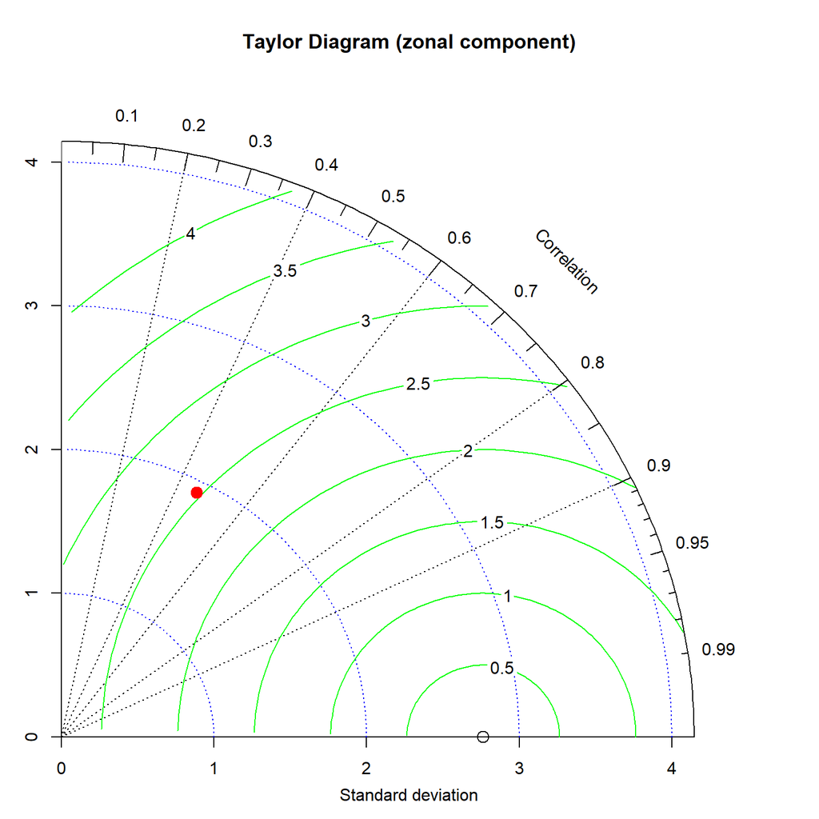

```r
# Taylor diagram for wind meridional component from buoy vs
# ERAI wind speed (combined U & V)
taylor_diagram_V <- taylor.diagram(wind_uv_components[, 2], windModel,
  pch = 19,
  pos.cor = TRUE,
  xlab = "Standard deviation",
  ylab = "Standard deviation",
  main = "Taylor Diagram (meridional component)",
  ngamma = 10,
  gamma.col = "green",
  sd.arcs = TRUE,
  pcex = 1.5
)
```

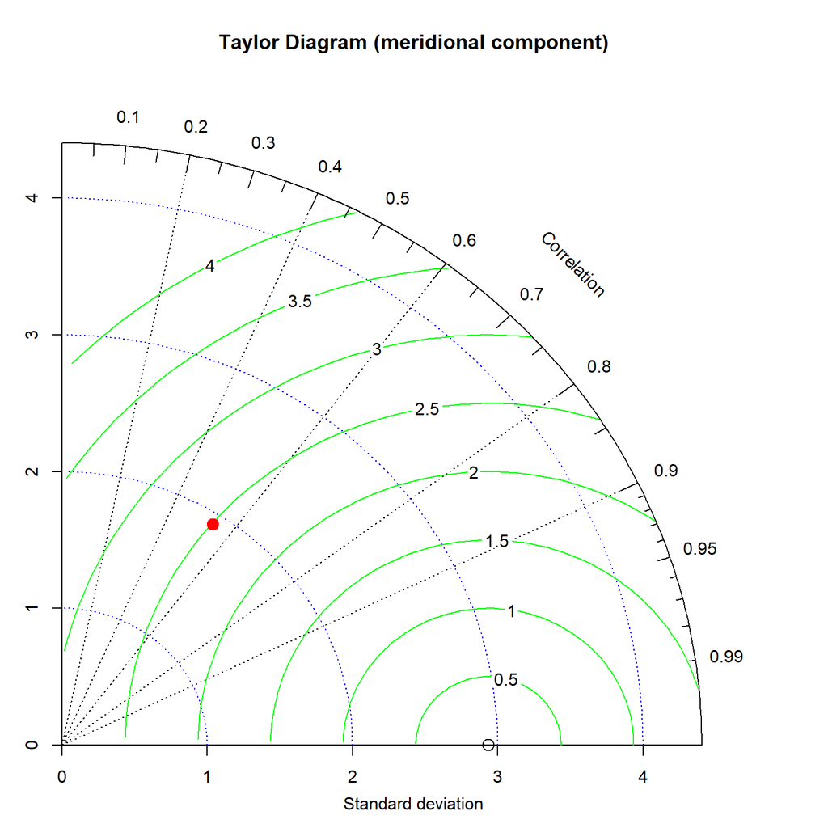